[figure not shown]

## mlcourse.ai - Open Machine Learning Course

Author: Vitaly Radchenko. All content is distributed under the [Creative Commons CC BY-NC-SA 4.0](https://creativecommons.org/licenses/by-nc-sa/4.0/) license.

# Assignment # 5 (demo)

## Logistic Regression and Random Forest in the credit scoring problem

**Same assignment as a [Kaggle Kernel](https://www.kaggle.com/kashnitsky/a5-demo-logit-and-rf-for-credit-scoring) + [solution](https://www.kaggle.com/kashnitsky/a5-demo-logit-and-rf-for-credit-scoring-sol).**

In this assignment, you will build models and answer questions using data on credit scoring.

Please write your code in the cells with the "Your code here" placeholder. Then, answer the questions in the [form](https://docs.google.com/forms/d/1gKt0DA4So8ohKAHZNCk58ezvg7K_tik26d9QND7WC6M/edit).

Let's start with a warm-up exercise.

**Question 1.** There are 5 jurors in a courtroom. Each of them can correctly identify the guilt of the defendant with 70% probability, independent of one another. What is the probability that the jurors will jointly reach the correct verdict if the final decision is by majority vote?

1. 70.00%
2. 83.20%
3. 83.70%
4. 87.50%

#### (0.7)^5 + 5C1 *(0.7)^4* (0.3) + 5C2 *(0.7)^3* (0.3)^2 = 0.8370

Great! Let's move on to machine learning.

## Credit scoring problem setup

#### Problem

Predict whether the customer will repay their credit within 90 days. This is a binary classification problem; we will assign customers into good or bad categories based on our prediction.

#### Data description

| Feature | Variable Type | Value Type | Description |
| --- | --- | --- | --- |
| age | Input Feature | integer | Customer age |
| DebtRatio | Input Feature | real | Total monthly loan payments (loan, alimony, etc.) / Total monthly income percentage |
| NumberOfTime30-59DaysPastDueNotWorse | Input Feature | integer | The number of cases when client has overdue 30-59 days (not worse) on other loans during the last 2 years |
| NumberOfTimes90DaysLate | Input Feature | integer | Number of cases when customer had 90+dpd overdue on other credits |
| NumberOfTime60-89DaysPastDueNotWorse | Input Feature | integer | Number of cased when customer has 60-89dpd (not worse) during the last 2 years |
| NumberOfDependents | Input Feature | integer | The number of customer dependents |
| SeriousDlqin2yrs | Target Variable | binary: 0 or 1 | Customer hasn't paid the loan debt within 90 days |

Let's set up our environment:

```python
# Disable warnings in Anaconda
import warnings
warnings.filterwarnings('ignore')

import numpy as np
import pandas as pd
%matplotlib inline
import matplotlib.pyplot as plt
import seaborn as sns
sns.set()
```

```python
from matplotlib import rcParams
rcParams['figure.figsize'] = 11, 8
```

Let's write the function that will replace *NaN* values with the median for each column.

```python
def fill_nan(table):
    for col in table.columns:
        table[col] = table[col].fillna(table[col].median())
    return table
```

Now, read the data:

```python
data = pd.read_csv('../../data/credit_scoring_sample.csv', sep =';')
data.head()
```

|  | SeriousDlqin2yrs | age | NumberOfTime30-59DaysPastDueNotWorse | DebtRatio | NumberOfTimes90DaysLate | NumberOfTime60-89DaysPastDueNotWorse | MonthlyIncome | NumberOfDependents |
| --- | --- | --- | --- | --- | --- | --- | --- | --- |
| 0 | 0 | 64 | 0 | 0.249908 | 0 | 0 | 8158.0 | 0.0 |
| 1 | 0 | 58 | 0 | 3870.000000 | 0 | 0 | NaN | 0.0 |
| 2 | 0 | 41 | 0 | 0.456127 | 0 | 0 | 6666.0 | 0.0 |
| 3 | 0 | 43 | 0 | 0.000190 | 0 | 0 | 10500.0 | 2.0 |
| 4 | 1 | 49 | 0 | 0.271820 | 0 | 0 | 400.0 | 0.0 |

Look at the variable types:

```python
data.dtypes
```

```
SeriousDlqin2yrs                          int64
age                                       int64
NumberOfTime30-59DaysPastDueNotWorse      int64
DebtRatio                               float64
NumberOfTimes90DaysLate                   int64
NumberOfTime60-89DaysPastDueNotWorse      int64
MonthlyIncome                           float64
NumberOfDependents                      float64
dtype: object
```

Check the class balance:

```
Distribution of the target:
```

```
0    0.777511
1    0.222489
Name: SeriousDlqin2yrs, dtype: float64
```

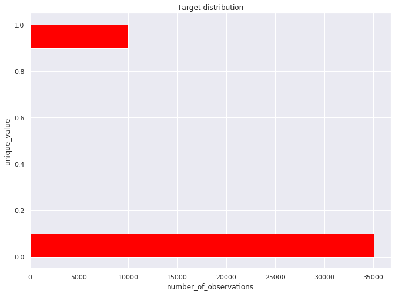

```python
ax = data['SeriousDlqin2yrs'].hist(orientation='horizontal', color='red')
ax.set_xlabel("number_of_observations")
ax.set_ylabel("unique_value")
ax.set_title("Target distribution")

print('Distribution of the target:')
data['SeriousDlqin2yrs'].value_counts()/data.shape[0]
```

Separate the input variable names by excluding the target:

```python
independent_columns_names = [x for x in data if x != 'SeriousDlqin2yrs']
independent_columns_names
```

```
['age',
 'NumberOfTime30-59DaysPastDueNotWorse',
 'DebtRatio',
 'NumberOfTimes90DaysLate',
 'NumberOfTime60-89DaysPastDueNotWorse',
 'MonthlyIncome',
 'NumberOfDependents']
```

Apply the function to replace *NaN* values:

```python
table = fill_nan(data)
```

Separate the target variable and input features:

```python
X = table[independent_columns_names]
y = table['SeriousDlqin2yrs']
```

## Bootstrapping

**Question 2.** Make an interval estimate of the average age for the customers who delayed repayment at the 90% confidence level. Use the example from the article as reference, if needed. Also, use `np.random.seed(0)` as before. What is the resulting interval estimate?

```python
def get_bootstrap_samples(data, n_samples):
    ind = np.random.randint(0, len(data), (n_samples, len(data)))
    return data[ind]
```

```python
def stat_intervals(stat, alpha):
    return np.percentile(stat, [100 * alpha/2. , 100 * (1 - alpha/2.)])
```

```python
np.random.seed(0)
```

```python
defaulters = data[data['SeriousDlqin2yrs'] == 1]['age'].values
```

```python
bootstrap_def = [np.mean(x) for x in get_bootstrap_samples(defaulters, 2000)]
```

```python
print("Mean Interval, age: ", stat_intervals(bootstrap_def, 0.1))
```

```
Mean Interval, age:  [45.71508578 46.12828147]
```

## Logistic regression

Let's set up to use logistic regression:

```python
from sklearn.linear_model import LogisticRegression
from sklearn.model_selection import GridSearchCV, StratifiedKFold
```

Now, we will create a `LogisticRegression` model and use `class_weight='balanced'` to make up for our unbalanced classes.

```python
lr = LogisticRegression(random_state=5, class_weight='balanced')
```

Let's try to find the best regularization coefficient, which is the coefficient `C` for logistic regression. Then, we will have an optimal model that is not overfit and is a good predictor of the target variable.

```python
parameters = {'C': (0.0001, 0.001, 0.01, 0.1, 1, 10)}
```

In order to find the optimal value of `C`, let's apply stratified 5-fold validation and look at the *ROC AUC* against different values of the parameter `C`. Use the `StratifiedKFold` function for this:

```python
skf = StratifiedKFold(n_splits=5, shuffle=True, random_state=5)
```

One of the important metrics of model quality is the *Area Under the Curve (AUC)*. *ROC AUC* varies from 0 to 1. The closer ROC AUC is to 1, the better the quality of the classification model.

**Question 3.** Perform a *Grid Search* with the scoring metric "roc_auc" for the parameter `C`. Which value of the parameter `C` is optimal?

1. 0.0001  
   **2. 0.001**
2. 0.01
3. 0.1
4. 1
5. 10

```python
gs = GridSearchCV(lr, parameters, cv=skf, n_jobs=-1, verbose=1, scoring='roc_auc')
gs.fit(X, y)
```

```
Fitting 5 folds for each of 6 candidates, totalling 30 fits
```

```
[Parallel(n_jobs=-1)]: Using backend LokyBackend with 4 concurrent workers.
[Parallel(n_jobs=-1)]: Done  30 out of  30 | elapsed:    5.4s finished
```

```
GridSearchCV(cv=StratifiedKFold(n_splits=5, random_state=5, shuffle=True),
             error_score='raise-deprecating',
             estimator=LogisticRegression(C=1.0, class_weight='balanced',
                                          dual=False, fit_intercept=True,
                                          intercept_scaling=1, l1_ratio=None,
                                          max_iter=100, multi_class='warn',
                                          n_jobs=None, penalty='l2',
                                          random_state=5, solver='warn',
                                          tol=0.0001, verbose=0,
                                          warm_start=False),
             iid='warn', n_jobs=-1,
             param_grid={'C': (0.0001, 0.001, 0.01, 0.1, 1, 10)},
             pre_dispatch='2*n_jobs', refit=True, return_train_score=False,
             scoring='roc_auc', verbose=1)
```

```python
gs.best_params_, gs.best_score_
```

```
({'C': 0.001}, 0.796206476909831)
```

**Question 4.** Can we consider the best model stable? The model is *stable* if the standard deviation on validation is less than 0.5%. Save the *ROC AUC* value of the best model; it will be useful for the following tasks.  
**1. Yes**

1. No

```python
gs.best_index_, gs.cv_results_['std_test_score'][gs.best_index_]
```

```
(1, 0.0035278855414392256)
```

## Feature importance

**Question 5.** *Feature importance* is defined by the absolute value of its corresponding coefficient. First, you need to normalize all of the feature values so that it will be valid to compare them. What is the most important feature for the best logistic regression model?

1. age  
   **2. NumberOfTime30-59DaysPastDueNotWorse**
2. DebtRatio
3. NumberOfTimes90DaysLate
4. NumberOfTime60-89DaysPastDueNotWorse
5. MonthlyIncome
6. NumberOfDependents

```python
from sklearn.preprocessing import StandardScaler

scale = StandardScaler()
lr = LogisticRegression(C=0.001, random_state=5, class_weight='balanced')
```

```python
scaled_X = scale.fit_transform(X)
```

```python
lr.fit(scaled_X, y)
```

```
LogisticRegression(C=0.001, class_weight='balanced', dual=False,
                   fit_intercept=True, intercept_scaling=1, l1_ratio=None,
                   max_iter=100, multi_class='warn', n_jobs=None, penalty='l2',
                   random_state=5, solver='warn', tol=0.0001, verbose=0,
                   warm_start=False)
```

```python
imp_df = pd.DataFrame({
    'features': independent_columns_names,
    'importance': lr.coef_.flatten()
}).sort_values(by='importance', ascending=False)
```

```python
imp_df.head(7)
```

|  | features | importance |
| --- | --- | --- |
| 1 | NumberOfTime30-59DaysPastDueNotWorse | 0.724004 |
| 3 | NumberOfTimes90DaysLate | 0.517673 |
| 4 | NumberOfTime60-89DaysPastDueNotWorse | 0.194732 |
| 6 | NumberOfDependents | 0.101326 |
| 2 | DebtRatio | -0.024082 |
| 5 | MonthlyIncome | -0.162864 |
| 0 | age | -0.416304 |

**Question 6.** Calculate how much `DebtRatio` affects our prediction using the [softmax function](https://en.wikipedia.org/wiki/Softmax_function). What is its value?

1. 0.38
2. -0.02  
   **3. 0.11**
3. 0.24

```python
def softmax(data, index):
    return np.exp(data[index])/ np.sum(np.exp(data))
```

```python
ind =imp_df[imp_df['features'] == 'DebtRatio'].index
```

```python
softmax(lr.coef_.flatten(), ind[0])
```

```
0.11420536719928262
```

**Question 7.** Let's see how we can interpret the impact of our features. For this, recalculate the logistic regression with absolute values, that is without scaling. Next, modify the customer's age by adding 20 years, keeping the other features unchanged. How many times will the chance that the customer will not repay their debt increase? You can find an example of the theoretical calculation [here](https://www.unm.edu/~schrader/biostat/bio2/Spr06/lec11.pdf).

1. -0.01  
   **2. 0.70**
2. 8.32
3. 0.66

```python
lr = LogisticRegression(C=0.001, random_state=5, class_weight='balanced')
lr.fit(X, y)

imp_df = pd.DataFrame({
    'features': independent_columns_names,
    'importance': lr.coef_.flatten()
}).sort_values(by='importance', ascending=False)

imp_df.head(7)
```

|  | features | importance |
| --- | --- | --- |
| 1 | NumberOfTime30-59DaysPastDueNotWorse | 0.482349 |
| 3 | NumberOfTimes90DaysLate | 0.430314 |
| 6 | NumberOfDependents | 0.115356 |
| 4 | NumberOfTime60-89DaysPastDueNotWorse | 0.065958 |
| 2 | DebtRatio | -0.000011 |
| 5 | MonthlyIncome | -0.000011 |
| 0 | age | -0.018185 |

```python
ind = imp_df[imp_df['features'] == 'age'].index
```

```python
softmax(lr.coef_.flatten(), ind[0])
```

```
0.1178842512010839
```

```python
np.exp(imp_df[imp_df['features'] == 'age']['importance']*20)
```

```
0    0.695096
Name: importance, dtype: float64
```

## Random Forest

Import the Random Forest classifier:

```python
from sklearn.ensemble import RandomForestClassifier
```

Initialize Random Forest with 100 trees and balance target classes:

```python
rf = RandomForestClassifier(n_estimators=100, n_jobs=-1, random_state=42,
                            class_weight='balanced')
```

We will search for the best parameters among the following values:

```python
parameters = {'max_features': [1, 2, 4], 'min_samples_leaf': [3, 5, 7, 9], 'max_depth': [5,10,15]}
```

Also, we will use the stratified k-fold validation again. You should still have the `skf` variable.

**Question 8.** How much higher is the *ROC AUC* of the best random forest model than that of the best logistic regression on validation?  
**1. 4%**

1. 3%
2. 2%
3. 1%

```python
# Your code here
skf = StratifiedKFold(n_splits=5, shuffle=True, random_state=42)
```

```python
gs = GridSearchCV(rf, parameters, cv=skf, n_jobs=-1, verbose=1, scoring='roc_auc')
```

```python
gs.fit(X, y)
```

```
Fitting 5 folds for each of 36 candidates, totalling 180 fits
```

```
[Parallel(n_jobs=-1)]: Using backend LokyBackend with 4 concurrent workers.
[Parallel(n_jobs=-1)]: Done  42 tasks      | elapsed:   33.0s
[Parallel(n_jobs=-1)]: Done 180 out of 180 | elapsed:  4.5min finished
```

```
GridSearchCV(cv=StratifiedKFold(n_splits=5, random_state=42, shuffle=True),
             error_score='raise-deprecating',
             estimator=RandomForestClassifier(bootstrap=True,
                                              class_weight='balanced',
                                              criterion='gini', max_depth=None,
                                              max_features='auto',
                                              max_leaf_nodes=None,
                                              min_impurity_decrease=0.0,
                                              min_impurity_split=None,
                                              min_samples_leaf=1,
                                              min_samples_split=2,
                                              min_weight_fraction_leaf=0.0,
                                              n_estimators=100, n_jobs=-1,
                                              oob_score=False, random_state=42,
                                              verbose=0, warm_start=False),
             iid='warn', n_jobs=-1,
             param_grid={'max_depth': [5, 10, 15], 'max_features': [1, 2, 4],
                         'min_samples_leaf': [3, 5, 7, 9]},
             pre_dispatch='2*n_jobs', refit=True, return_train_score=False,
             scoring='roc_auc', verbose=1)
```

```python
gs.best_params_, gs.best_score_ , (gs.best_score_ - 0.796206476909831) * 100
```

```
({'max_depth': 10, 'max_features': 2, 'min_samples_leaf': 9},
 0.8354072783213053,
 3.9200801411474306)
```

**Question 9.** What feature has the weakest impact in the Random Forest model?

1. age
2. NumberOfTime30-59DaysPastDueNotWorse
3. DebtRatio
4. NumberOfTimes90DaysLate
5. NumberOfTime60-89DaysPastDueNotWorse
6. MonthlyIncome  
   **7. NumberOfDependents**

```python
rf = RandomForestClassifier(n_estimators=100, n_jobs=-1, random_state=42,
                            max_depth=10, max_features=2, min_samples_leaf=9,
                            class_weight='balanced')

rf.fit(X, y)
```

```
RandomForestClassifier(bootstrap=True, class_weight='balanced',
                       criterion='gini', max_depth=10, max_features=2,
                       max_leaf_nodes=None, min_impurity_decrease=0.0,
                       min_impurity_split=None, min_samples_leaf=9,
                       min_samples_split=2, min_weight_fraction_leaf=0.0,
                       n_estimators=100, n_jobs=-1, oob_score=False,
                       random_state=42, verbose=0, warm_start=False)
```

```python
imp_df = pd.DataFrame({
    'features': independent_columns_names,
    'importance': rf.feature_importances_.flatten()
}).sort_values(by='importance', ascending=False)

imp_df.head(7)
```

|  | features | importance |
| --- | --- | --- |
| 1 | NumberOfTime30-59DaysPastDueNotWorse | 0.301419 |
| 3 | NumberOfTimes90DaysLate | 0.278862 |
| 4 | NumberOfTime60-89DaysPastDueNotWorse | 0.153586 |
| 0 | age | 0.116950 |
| 2 | DebtRatio | 0.076190 |
| 5 | MonthlyIncome | 0.058536 |
| 6 | NumberOfDependents | 0.014457 |

**Question 10.** What is the most significant advantage of using *Logistic Regression* versus *Random Forest* for this problem?

1. Spent less time for model fitting;
2. Fewer variables to iterate;  
   **3. Feature interpretability;**
3. Linear properties of the algorithm.

## Bagging

Import modules and set up the parameters for bagging:

```python
from sklearn.ensemble import BaggingClassifier
from sklearn.model_selection import cross_val_score, RandomizedSearchCV

parameters = {'max_features': [2, 3, 4], 'max_samples': [0.5, 0.7, 0.9],
              'base_estimator__C': [0.0001, 0.001, 0.01, 1, 10, 100]}
```

```python
skf = StratifiedKFold(n_splits=5, shuffle=True, random_state=1)
```

```python
lr = LogisticRegression(class_weight='balanced', random_state=1)

bg = BaggingClassifier(lr, n_estimators=100, n_jobs=-1, random_state=1)
```

```python
rs = RandomizedSearchCV(bg, parameters, n_jobs=-1, n_iter=40, random_state=1, verbose=True, cv=skf, scoring='roc_auc')
```

```python
rs.fit(X, y)
```

```
Fitting 5 folds for each of 40 candidates, totalling 200 fits
```

```
[Parallel(n_jobs=-1)]: Using backend LokyBackend with 4 concurrent workers.
[Parallel(n_jobs=-1)]: Done  42 tasks      | elapsed:  4.1min
[Parallel(n_jobs=-1)]: Done 192 tasks      | elapsed: 17.8min
[Parallel(n_jobs=-1)]: Done 200 out of 200 | elapsed: 18.4min finished
```

```
RandomizedSearchCV(cv=StratifiedKFold(n_splits=5, random_state=1, shuffle=True),
                   error_score='raise-deprecating',
                   estimator=BaggingClassifier(base_estimator=LogisticRegression(C=1.0,
                                                                                 class_weight='balanced',
                                                                                 dual=False,
                                                                                 fit_intercept=True,
                                                                                 intercept_scaling=1,
                                                                                 l1_ratio=None,
                                                                                 max_iter=100,
                                                                                 multi_class='warn',
                                                                                 n_jobs=None,
                                                                                 penalty='l2',
                                                                                 random_state=1,
                                                                                 solver='warn...
                                               max_samples=1.0,
                                               n_estimators=100, n_jobs=-1,
                                               oob_score=False, random_state=1,
                                               verbose=0, warm_start=False),
                   iid='warn', n_iter=40, n_jobs=-1,
                   param_distributions={'base_estimator__C': [0.0001, 0.001,
                                                              0.01, 1, 10,
                                                              100],
                                        'max_features': [2, 3, 4],
                                        'max_samples': [0.5, 0.7, 0.9]},
                   pre_dispatch='2*n_jobs', random_state=1, refit=True,
                   return_train_score=False, scoring='roc_auc', verbose=True)
```

```python
rs.best_params_, rs.best_score_
```

```
({'max_samples': 0.5, 'max_features': 2, 'base_estimator__C': 0.01},
 0.8047280535298262)
```

**Question 12.** Give an interpretation of the best parameters for bagging. Why are these values of `max_features` and `max_samples` the best?

1. For bagging it's important to use as few features as possible;
2. Bagging works better on small samples;  
   **3. Less correlation between single models;**
3. The higher the number of features, the lower the loss of information.